# day22(18-06-2020)

## Assignment(day-22:18-6-20)

### Take any dataset of your choice from Kaggle or UCI and do the analysis on the data

#### Dataset Link: https://raw.githubusercontent.com/Mounika-Kajjam/Datasets/master/titanic.csv

- Load the dataset in a proper structure
- Get the number of rows and columns from the dataset
- Check how many categorical and numerical columns are there
  > - Categorical - object type
  > - Numerical - int,float
  > - Boolean - bool
- Get the basic descriptive information from the dataset
- Get the frequency of the categories in all the columns of the dataset
- Check for the missing values and if found any visualize the missing values using seaborn, missingno libraries.
- Impute the missing values based on numerical and categorical
- Plot all the columns from the dataset; try to get some observations from the plot and write your inferences below the plots generated
- Select any column as output from the dataset and plot the output column with some of the input columns, which are suitable from your data columns
- Encode the categorical columns using different kinds of encoding techniques from pandas and scikit-learn

#### Load the dataset in a proper structure

```python
#importing required libraries
import pandas as pd
import numpy as np
import seaborn as sns
import matplotlib.pyplot as plt
import sklearn
%matplotlib inline
```

```python
#importing data set
df = pd.read_csv("titanic.csv")
df
```

[output not shown]

```python
df = pd.read_csv("C:\\Users\\Deepthi\\Desktop\\deepu\\DS PYTHON\\titanic.csv")
df.head()
```

|  | PassengerId | Survived | Pclass | Name | Sex | Age | SibSp | Parch | Ticket | Fare | Cabin | Embarked |
| --- | --- | --- | --- | --- | --- | --- | --- | --- | --- | --- | --- | --- |
| 0 | 1 | 0 | 3 | Braund, Mr. Owen Harris | male | 22.0 | 1 | 0 | A/5 21171 | 7.2500 | NaN | S |
| 1 | 2 | 1 | 1 | Cumings, Mrs. John Bradley (Florence Briggs Th... | female | 38.0 | 1 | 0 | PC 17599 | 71.2833 | C85 | C |
| 2 | 3 | 1 | 3 | Heikkinen, Miss. Laina | female | 26.0 | 0 | 0 | STON/O2. 3101282 | 7.9250 | NaN | S |
| 3 | 4 | 1 | 1 | Futrelle, Mrs. Jacques Heath (Lily May Peel) | female | 35.0 | 1 | 0 | 113803 | 53.1000 | C123 | S |
| 4 | 5 | 0 | 3 | Allen, Mr. William Henry | male | 35.0 | 0 | 0 | 373450 | 8.0500 | NaN | S |

#### Get the number of rows and columns from the dataset

```python
#Get the number of rows and columns from the dataset
print("Rows :",len(df.axes[0]))
print("Columns :",len(df.axes[1]))
```

```
Rows : 891
Columns : 12
```

#### Check how many categorical and numerical columns are there

```python
print(len(df.select_dtypes(include=['object']).columns)) # no of Categorial columns
print(len(df.select_dtypes(include=['int64','float64']).columns)) # no of Numerical columns
```

```
5
7
```

#### Get the basic descriptive information from the dataset

```python
df.describe()
```

|  | PassengerId | Survived | Pclass | Age | SibSp | Parch | Fare |
| --- | --- | --- | --- | --- | --- | --- | --- |
| count | 891.000000 | 891.000000 | 891.000000 | 714.000000 | 891.000000 | 891.000000 | 891.000000 |
| mean | 446.000000 | 0.383838 | 2.308642 | 29.699118 | 0.523008 | 0.381594 | 32.204208 |
| std | 257.353842 | 0.486592 | 0.836071 | 14.526497 | 1.102743 | 0.806057 | 49.693429 |
| min | 1.000000 | 0.000000 | 1.000000 | 0.420000 | 0.000000 | 0.000000 | 0.000000 |
| 25% | 223.500000 | 0.000000 | 2.000000 | 20.125000 | 0.000000 | 0.000000 | 7.910400 |
| 50% | 446.000000 | 0.000000 | 3.000000 | 28.000000 | 0.000000 | 0.000000 | 14.454200 |
| 75% | 668.500000 | 1.000000 | 3.000000 | 38.000000 | 1.000000 | 0.000000 | 31.000000 |
| max | 891.000000 | 1.000000 | 3.000000 | 80.000000 | 8.000000 | 6.000000 | 512.329200 |

#### Get the frequency of the categories in all the columns of the dataset

```python
df.info()
```

```
<class 'pandas.core.frame.DataFrame'>
RangeIndex: 891 entries, 0 to 890
Data columns (total 12 columns):
PassengerId    891 non-null int64
Survived       891 non-null int64
Pclass         891 non-null int64
Name           891 non-null object
Sex            891 non-null object
Age            714 non-null float64
SibSp          891 non-null int64
Parch          891 non-null int64
Ticket         891 non-null object
Fare           891 non-null float64
Cabin          204 non-null object
Embarked       889 non-null object
dtypes: float64(2), int64(5), object(5)
memory usage: 83.7+ KB
```

```python
df.columns.value_counts()
```

```
Name           1
Ticket         1
Cabin          1
Age            1
Survived       1
Fare           1
Sex            1
Parch          1
Embarked       1
Pclass         1
SibSp          1
PassengerId    1
dtype: int64
```

#### Check for the missing values and if found any visualize the missing values using seaborn, missingno libraries.

```python
df.isnull().sum()
```

```
PassengerId      0
Survived         0
Pclass           0
Name             0
Sex              0
Age            177
SibSp            0
Parch            0
Ticket           0
Fare             0
Cabin          687
Embarked         2
dtype: int64
```

##### using seaborn library:

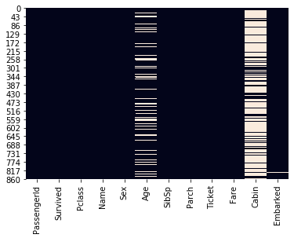

```python
sns.heatmap(df.isnull(), cbar=False)
```

##### using missingno library:

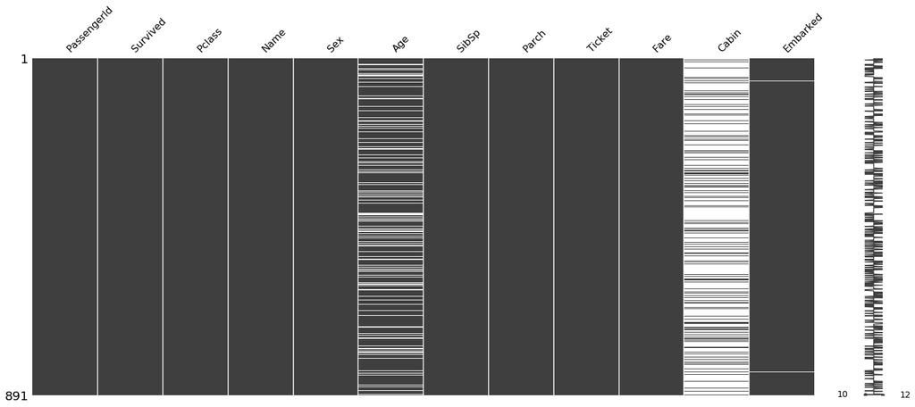

```python
import missingno as msno
msno.matrix(df)
```

##### mean imputation for numerical data:

```python
df_mean_imputed = df.fillna(df.mean())
df = df_mean_imputed
df
```

|  | PassengerId | Survived | Pclass | Name | Sex | Age | SibSp | Parch | Ticket | Fare | Cabin | Embarked |
| --- | --- | --- | --- | --- | --- | --- | --- | --- | --- | --- | --- | --- |
| 0 | 1 | 0 | 3 | Braund, Mr. Owen Harris | male | 22.000000 | 1 | 0 | A/5 21171 | 7.2500 | NaN | S |
| 1 | 2 | 1 | 1 | Cumings, Mrs. John Bradley (Florence Briggs Th... | female | 38.000000 | 1 | 0 | PC 17599 | 71.2833 | C85 | C |
| 2 | 3 | 1 | 3 | Heikkinen, Miss. Laina | female | 26.000000 | 0 | 0 | STON/O2. 3101282 | 7.9250 | NaN | S |
| 3 | 4 | 1 | 1 | Futrelle, Mrs. Jacques Heath (Lily May Peel) | female | 35.000000 | 1 | 0 | 113803 | 53.1000 | C123 | S |
| 4 | 5 | 0 | 3 | Allen, Mr. William Henry | male | 35.000000 | 0 | 0 | 373450 | 8.0500 | NaN | S |
| ... | ... | ... | ... | ... | ... | ... | ... | ... | ... | ... | ... | ... |
| 886 | 887 | 0 | 2 | Montvila, Rev. Juozas | male | 27.000000 | 0 | 0 | 211536 | 13.0000 | NaN | S |
| 887 | 888 | 1 | 1 | Graham, Miss. Margaret Edith | female | 19.000000 | 0 | 0 | 112053 | 30.0000 | B42 | S |
| 888 | 889 | 0 | 3 | Johnston, Miss. Catherine Helen "Carrie" | female | 29.699118 | 1 | 2 | W./C. 6607 | 23.4500 | NaN | S |
| 889 | 890 | 1 | 1 | Behr, Mr. Karl Howell | male | 26.000000 | 0 | 0 | 111369 | 30.0000 | C148 | C |
| 890 | 891 | 0 | 3 | Dooley, Mr. Patrick | male | 32.000000 | 0 | 0 | 370376 | 7.7500 | NaN | Q |

891 rows × 12 columns

#### Impute the missing values based on numerical and categorical

```python
df.isnull().sum()
```

```
PassengerId      0
Survived         0
Pclass           0
Name             0
Sex              0
Age              0
SibSp            0
Parch            0
Ticket           0
Fare             0
Cabin          687
Embarked         2
dtype: int64
```

##### categorical data:

```python
df['Cabin'] = df['Cabin'].fillna(df.Cabin.mode().iloc[0])
df.Cabin.isna().sum()
```

```
0
```

```python
df['Embarked'] = df['Embarked'].fillna(df.Embarked.mode().iloc[0])
df.Cabin.isna().sum()
```

```
0
```

```python
df.isnull().sum()
```

```
PassengerId    0
Survived       0
Pclass         0
Name           0
Sex            0
Age            0
SibSp          0
Parch          0
Ticket         0
Fare           0
Cabin          0
Embarked       0
dtype: int64
```

```
array([[<matplotlib.axes._subplots.AxesSubplot object at 0x00000205AD6C5DC8>,
      dtype=object)
```

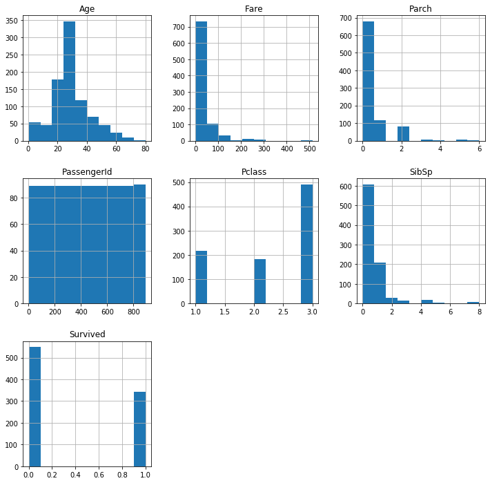

```python
df.hist(figsize=(12,12))
```

```python
df.Sex.value_counts(normalize=True)
```

```
male      0.647587
female    0.352413
Name: Sex, dtype: float64
```

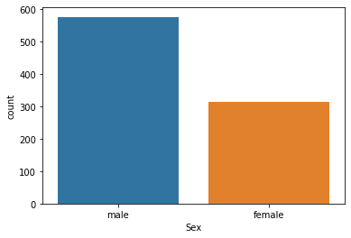

```python
sns.countplot(df['Sex'])
```

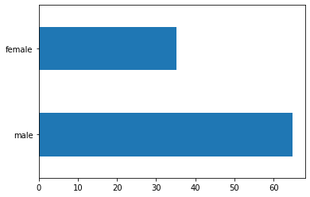

```python
(df.Sex.value_counts(normalize=True)*100).plot.barh()
```

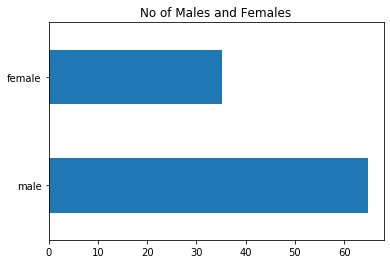

```python
(df.Sex.value_counts(normalize=True)*100).plot.barh().set_title("No of Males and Females")
```

#### Encode the categorical columns using different kinds of encoding techniques from pandas and scikit-learn

```python
df= pd.concat([df,pd.get_dummies(df.Cabin,prefix='Cabin',drop_first=True)])
df
```

|  | Age | Cabin | Cabin_A14 | Cabin_A16 | Cabin_A19 | Cabin_A20 | Cabin_A23 | Cabin_A24 | Cabin_A26 | Cabin_A31 | ... | Embarked | Fare | Name | Parch | PassengerId | Pclass | Sex | SibSp | Survived | Ticket |
| --- | --- | --- | --- | --- | --- | --- | --- | --- | --- | --- | --- | --- | --- | --- | --- | --- | --- | --- | --- | --- | --- |
| 0 | 22.0 | B96 B98 | NaN | NaN | NaN | NaN | NaN | NaN | NaN | NaN | ... | S | 7.2500 | Braund, Mr. Owen Harris | 0.0 | 1.0 | 3.0 | male | 1.0 | 0.0 | A/5 21171 |
| 1 | 38.0 | C85 | NaN | NaN | NaN | NaN | NaN | NaN | NaN | NaN | ... | C | 71.2833 | Cumings, Mrs. John Bradley (Florence Briggs Th... | 0.0 | 2.0 | 1.0 | female | 1.0 | 1.0 | PC 17599 |
| 2 | 26.0 | B96 B98 | NaN | NaN | NaN | NaN | NaN | NaN | NaN | NaN | ... | S | 7.9250 | Heikkinen, Miss. Laina | 0.0 | 3.0 | 3.0 | female | 0.0 | 1.0 | STON/O2. 3101282 |
| 3 | 35.0 | C123 | NaN | NaN | NaN | NaN | NaN | NaN | NaN | NaN | ... | S | 53.1000 | Futrelle, Mrs. Jacques Heath (Lily May Peel) | 0.0 | 4.0 | 1.0 | female | 1.0 | 1.0 | 113803 |
| 4 | 35.0 | B96 B98 | NaN | NaN | NaN | NaN | NaN | NaN | NaN | NaN | ... | S | 8.0500 | Allen, Mr. William Henry | 0.0 | 5.0 | 3.0 | male | 0.0 | 0.0 | 373450 |
| ... | ... | ... | ... | ... | ... | ... | ... | ... | ... | ... | ... | ... | ... | ... | ... | ... | ... | ... | ... | ... | ... |
| 886 | NaN | NaN | 0.0 | 0.0 | 0.0 | 0.0 | 0.0 | 0.0 | 0.0 | 0.0 | ... | NaN | NaN | NaN | NaN | NaN | NaN | NaN | NaN | NaN | NaN |
| 887 | NaN | NaN | 0.0 | 0.0 | 0.0 | 0.0 | 0.0 | 0.0 | 0.0 | 0.0 | ... | NaN | NaN | NaN | NaN | NaN | NaN | NaN | NaN | NaN | NaN |
| 888 | NaN | NaN | 0.0 | 0.0 | 0.0 | 0.0 | 0.0 | 0.0 | 0.0 | 0.0 | ... | NaN | NaN | NaN | NaN | NaN | NaN | NaN | NaN | NaN | NaN |
| 889 | NaN | NaN | 0.0 | 0.0 | 0.0 | 0.0 | 0.0 | 0.0 | 0.0 | 0.0 | ... | NaN | NaN | NaN | NaN | NaN | NaN | NaN | NaN | NaN | NaN |
| 890 | NaN | NaN | 0.0 | 0.0 | 0.0 | 0.0 | 0.0 | 0.0 | 0.0 | 0.0 | ... | NaN | NaN | NaN | NaN | NaN | NaN | NaN | NaN | NaN | NaN |

1782 rows × 158 columns